# Juvenile Snowshoe Hares in Bonanza Creek Experimental Forest Report (ROZAL)

Sam Rozal

11/6/2021

# 1. Introduction

This report provides an exploratory overview into differences in weights and sizes of juvenile snowshoe hares observed at the Bonanza Creek Long Term Ecological Research site (a portion of the US Long Term Ecological Research Network) between the years of 1998 and 2012. Specifically, we visualize the differences in juvenile snowshoe hare weights between sexes (male and female) and experimental sites (Bonanza Riparian, Bonanza Mature, and Bonanza Black Spruce). A deeper statistical analysis analyzing differences between the average weight of male and female juvenile snowshoe hares is presented. We also farther explore the relationship between juvenile hare weight and juvenile hare hind foot length by building a simple linear regression model to explore this relationship

# 2. Data and Methods

Measurements pertaining to snowshoe hare sizes were collected by Dr. Knut Kielland, Dr. Staurt Chapin, Dr. Roger Russ, and their team between the years of 1998 and 2012 in the Bonanza Creek Experimental Forest in Alaska, USA. The data covers 5 sites (three of which are explored further in this report, as this report focuses on Juvenile snowshoe hares) where snowshoe hares were captured in traps, measured, and then released back into the the ecological reserve.Exploratory data visualization is first conducted in order to determine which variables warrant further investigation. Following this initial exploration, the difference between male and female weights is analysed using a Welch two-sample t-test (with a significance level of 0.05), the effect size of the model is found, and a linear regression model exploring weight and hind foot lengths is constructed.

# 3. Preliminary Results

## A. Annual Juvenile Hare Trap Counts

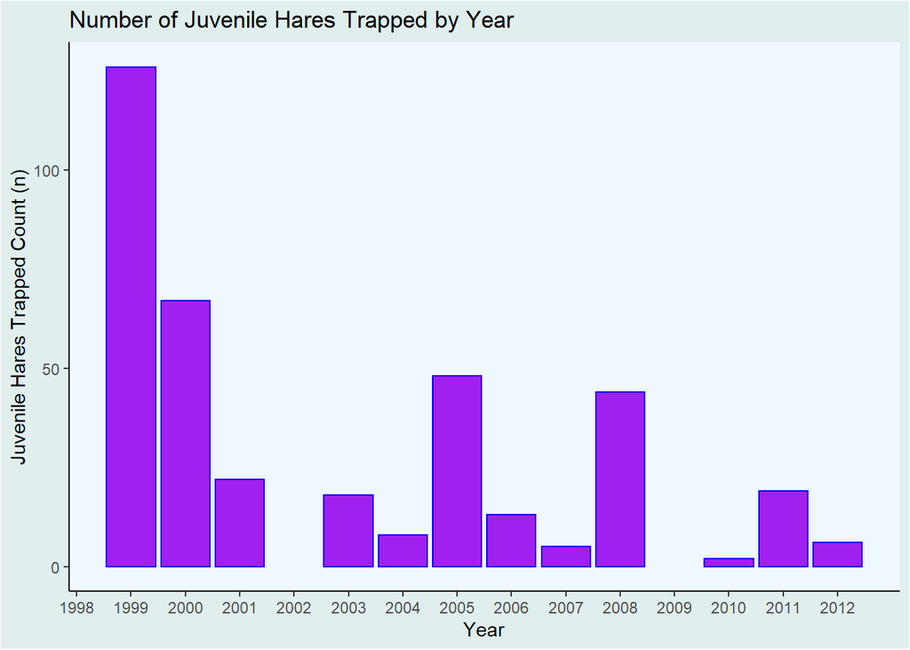

**Figure 1.Count of Juvenile Hares Trapped by year.** Bar values represent the total number of juvenile hares that were trapped and subsequently observed each year.

The number of observed hares greatly varied from year to year with a maximum number of hares trapped (126) occurring in 1999, and the minimum number of hares trapped (2) occurring in 2010. There was a mean value of 31.5 hares observed and a median value of 18.5 hares observed. These values, however, do not take into account effort as the number of traps set and number of days trapping was not standardized on a year to year basis. In order to more accurately asses year to year trends, it would be beneficial to divide by some value representing size, such as area of land studied or number of traps set.

## B.Juvenile hare weights

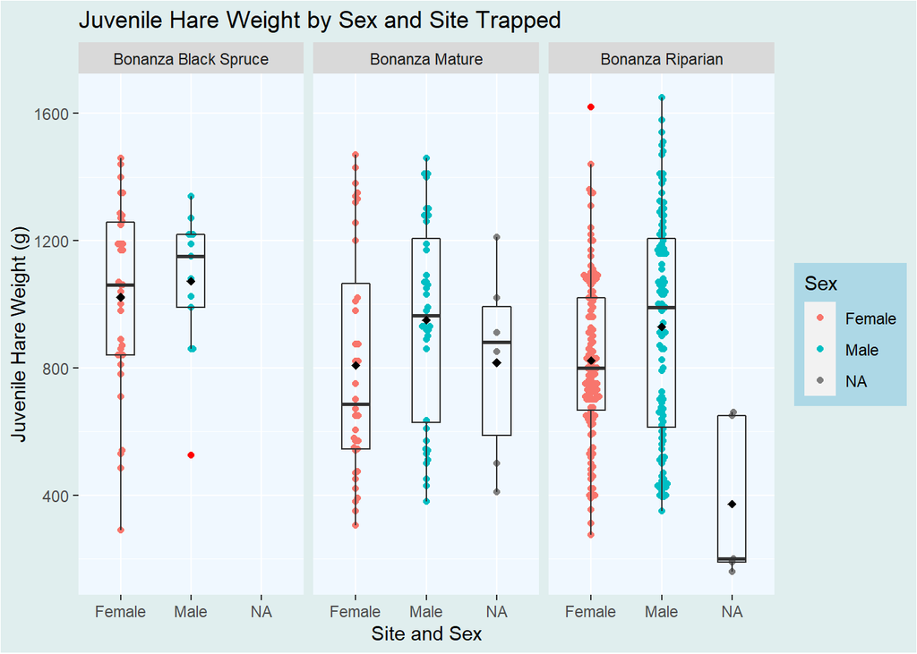

On average, across all three sites, male juvenile snowshoe hares were larger than that of female juvenile snowshoe hares. In comparing the size of the hares across the three sites, hares that were trapped at the Bonanza Black Spruce site were largest. We see the greatest distribution of sizes among male hares that were trapped at the Bonanza Riparian site.

## C.Comparison of Weights between Female and Male Snowshoe Hares

Table 1. Summary Statistics for Female, Male, and unknown sex (NA) Hares. Table includes mean, standard deviation, and sample size for Juvenile Hares of all sexes found at three diffent sites (Bonanza Riparian, Bonzana Mature, and Bonaza Black spruce) between the years of 1998 and 2012

| Sex | Mean Hare Weight (g) | Standard Deviation(g) | Sample Size (n) |
| --- | --- | --- | --- |
| Female | 855.39 | 292.25 | 200 |
| Male | 945.86 | 333.22 | 163 |
| NA | 614.55 | 357.59 | 15 |

Our analysis indicates that male juvenile snowshoe hares have a larger average weight compared to that of the average weight of female juvenile snowshoe hares (945.86 $\pm$ 333.22 and 855.39 $\pm$ 292.25 respectively, reported as mean $\pm$ 1 standard deviation). The absolute difference in means between females and males is 90.47 grams, which is a 10.05 percent difference. Exploratory qq plots and histograms indicated a normal distribution of residuals and data respectively, so a two sided t-test was warranted to assess the significance of this difference. The difference between these means is significant (t(325.02) = -2.71, p=0.0071) and the effects size is small (Cohen’s *d* =0.29). Data: Kielland et al. (2017)

## D. Relationship Between Weight and Hind Foot Length

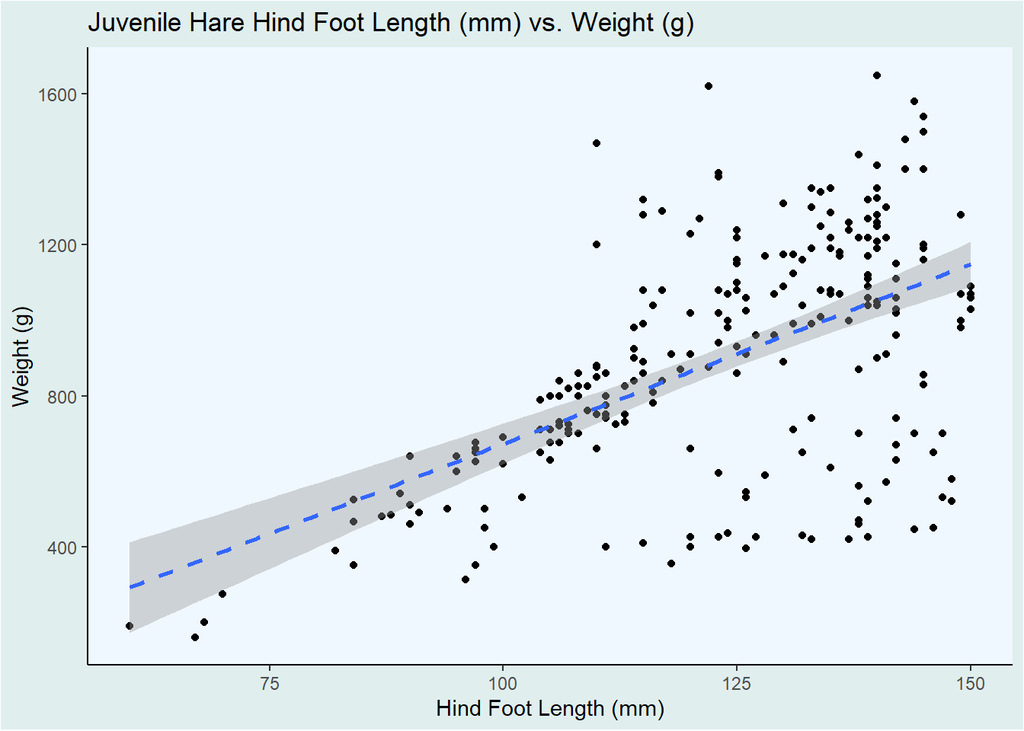

# 4. Summary

Future analysis surrounding this topic should include:

- Constructing a multivariate linear regression model to account for potentially significant variables (such as hare sex and observation site) that were not included in the current simple linear regression model.
- Test if the relationship between weight and hind leg length follows non-linear models such as exponential or logistic models.

# 5. Citation

**Data citation**: Kielland, K., F.S. Chapin, R.W. Ruess, and Bonanza Creek LTER. 2017. Snowshoe hare physical data in Bonanza Creek Experimental Forest: 1999-Present ver 22. Environmental Data Initiative. https://doi.org/10.6073/pasta/03dce4856d79b91557d8e6ce2cbcdc14